# Понимание Q-Q Plots. От долбоеба до профессионала за 1 гайд.

Vladimir Silkin

20 08 2021

Как понять, что выборка данных принадлежит определенному распределению? Есть 2 метода: аналитический тест Колмогорова-Смирнова (тест Шапиро-Уилка для нормального) и графический метод с помощью графика квантиль-квантиль плот.

Чем так замечателен второй вариант? Q-Q plot позволяет кроме принадлежности

- оценить степень отклонения данных от теоретического распределения
- графически проиллюстрировать такие параметры как расположение данных, масштаб и скошенность
- сравнить две выборки между собой (непараметрический подход к сопоставлению двух выборок)
- делать выводы, не основываясь на таких спорных показателях как $p.value$.

Фактически, $p.value$ во случае Q-Q Plots будет оценивать человеческий мозг на основе визуального анализа.

Как видите, графический метод является мощнейшим инструментом анализа, но как сказано в [англоязычной статье википедии про Q-Q Plots](https://en.m.wikipedia.org/wiki/Q–Q_plot), требует серьезных навыков для интерпретации.

В данной статье я представляю дорожную карту пути к пониманию квантильных графиков.

# 1. Квантили.

**Квантиль дискретной выборки** - это одна из точек, делящих упорядоченную последовательность чисел на равные части.

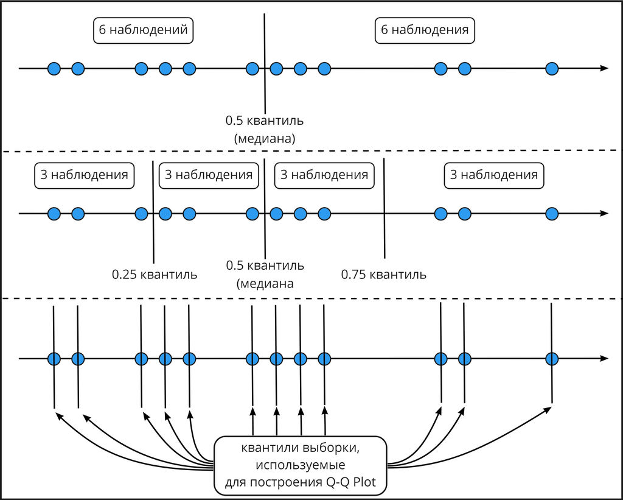

**Квантиль непрерывного распредления** - это одна из точек, делящих функцию плотности распределения на участки, вероятность попадания в которые одинакова, то есть на участки одинаоковой площади.

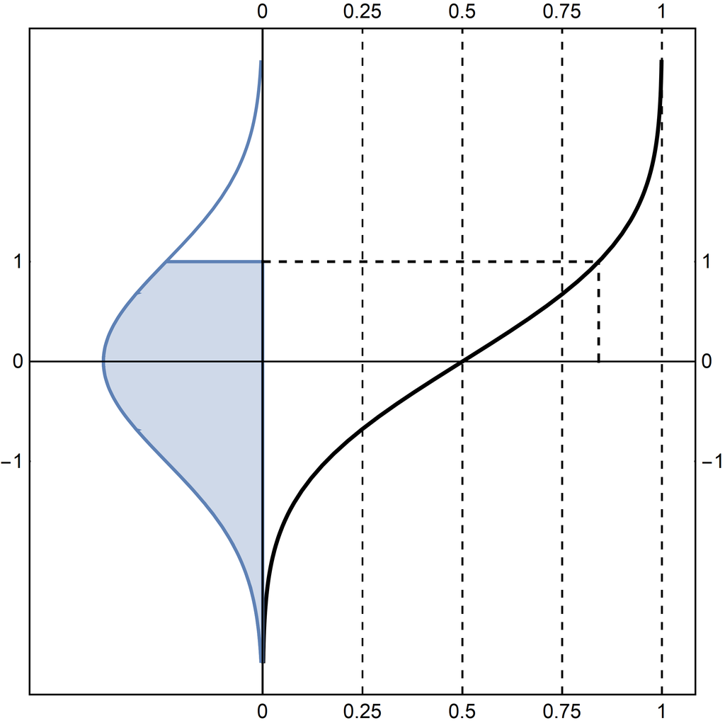

**Квантиль-функция** $-$ это функция, которая по значению вероятности $P$ возвращает такое число (квантиль) $q$, что вероятность того, что случайная величина примет значение меньше $q$ равняется $P$.

$$Quantile(P) = q: \:\:\:\: Probability(x<q) = P$$

Можно представлять себе квантиль-функцию непрерывного распределения, как зависимость арифметического уровеня воды в вазе, стенками которой является функция плотности вероятности $-$ от объема налитой воды. Эта интерпретация хорошо показана в [видео одного бразильского инструктора по статистике](https://www.youtube.com/user/profjohnbarroso1/about).

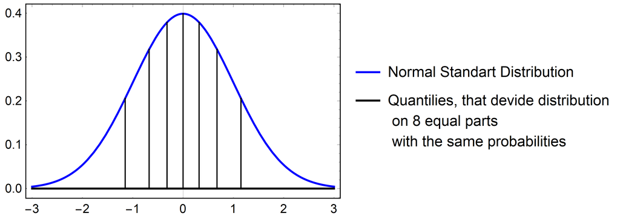

# 2. Квантиль-Квантиль plot

# Base plot

Для начала построим обычный наш базовый квантильный график - теоретических квантилей стандартного нормального распределения от теоретических квантилей стандартного нормального распределения. На следующей картинке в виде непрерывной прямой показана зависимость этих квантилей. Горизонтальные прямые делят зависимое распределение на 8 равных по плащади промежутков, а вертикальные прямые делят независимое распределение на промежутки с таким же смыслом.

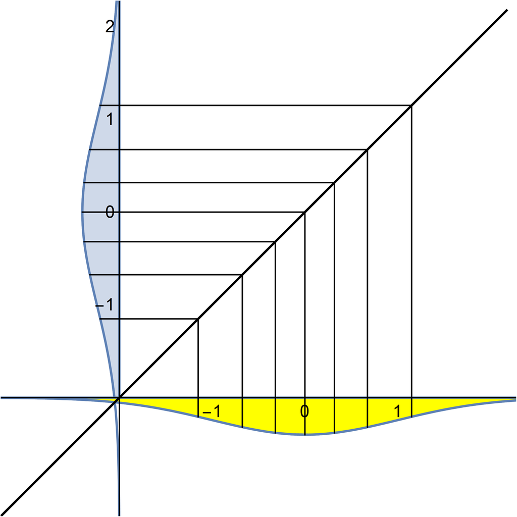

**Выводы:**

- В случае одинаковых распределений график квантильной зависимости представляет прямую линию.

## Физический смысл наклона линии тренда и значение q-q plot в нуле

А что будет, если зависимое распределение более дисперсно? А менее?

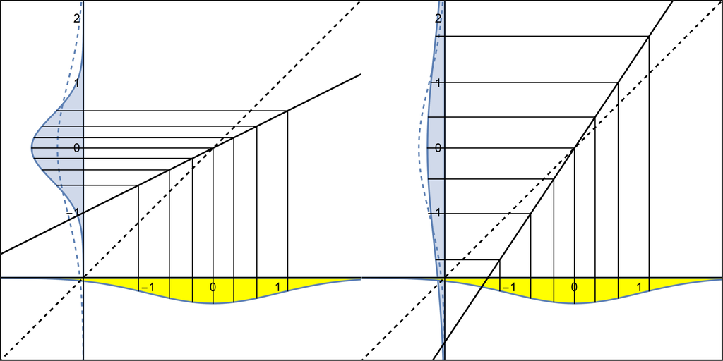

## Скошенные распределения

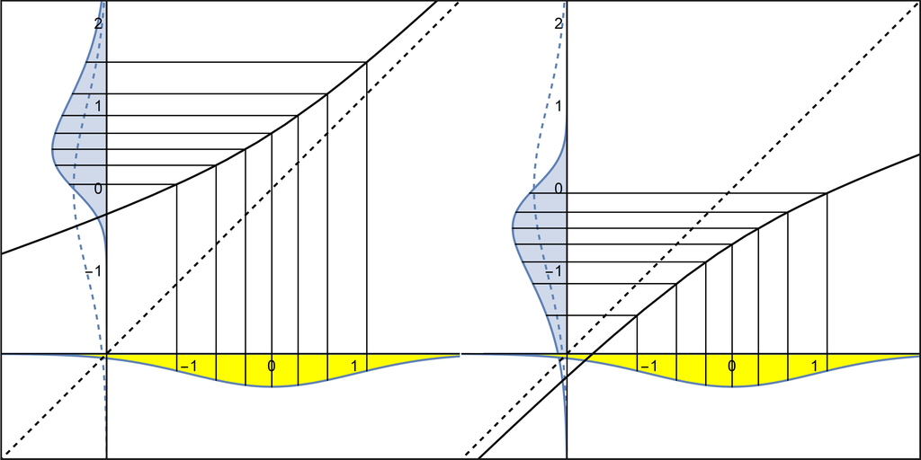

**Выводы:**

- Делайте сами